# 標高・傾斜度メッシュデータの可視化

伊豆地域の例

[岩田真一郎](https://shinichiro-iwata.github.io/)（ [神奈川大学経済学部](https://www.econ.kanagawa-u.ac.jp/)）

2024-04-13作成，2025-03-03改定

# 1 目的

- [国土数値情報](https://nlftp.mlit.go.jp/)の[標高・傾斜度5次メッシュ](https://nlftp.mlit.go.jp/ksj/gml/datalist/KsjTmplt-G04-d.html)を用いて静岡県伊豆地域（[伊豆エリア](https://hellonavi.jp/area/izu/index.html)）の平均[標高](https://ja.wikipedia.org/wiki/%E6%A8%99%E9%AB%98)と平均傾斜角度を可視化．
  - [伊豆観光公式サイト 美伊豆 B-Izu](https://b-izu.com/)，[伊豆半島とは](https://b-izu.com/about/)によると伊豆地域は以下の通り．

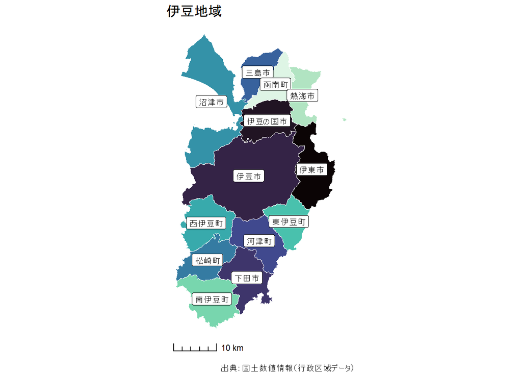

**パッケージ**：`sf`，`tidyverse`

```r
library(sf)
library(tidyverse)
```

# 2 標高・傾斜度メッシュデータ

## 2.1 ダウンロード

```r
#メッシュデータの読込
mesh_5138 <-
  read_sf("G04-d-11_5138-jgd_GML/G04-d-11_5138-jgd_ElevationAndSlopeAngleFifthMesh.shp",
          crs=6668)

mesh_5139 <-
  read_sf("G04-d-11_5139-jgd_GML/G04-d-11_5139-jgd_ElevationAndSlopeAngleFifthMesh.shp",
          crs=6668)

mesh_5238 <-
  read_sf("G04-d-11_5238-jgd_GML/G04-d-11_5238-jgd_ElevationAndSlopeAngleFifthMesh.shp",
          crs=6668)

mesh_5239 <-
  read_sf("G04-d-11_5239-jgd_GML/G04-d-11_5239-jgd_ElevationAndSlopeAngleFifthMesh.shp",
          crs=6668)
```

## 2.2 データの結合・加工

- 4つのメッシュデータを1つにまとめる（`rbind`）．縦方向に長くなる．
- 利用する列（変数）は次の2つ．
  - 平均標高（`G04d_002`列）
  - 平均傾斜角度（`G04d_010`列）
- 平均標高，平均傾斜角度を連続変数として扱えるように数値に変更（`as.numeric()`）．

```r
#結合
mesh <-
  rbind(mesh_5138, mesh_5139,
        mesh_5238, mesh_5239)

#数値化
mesh <- mesh %>%
  mutate(G04d_002=as.numeric(G04d_002),
         G04d_010=as.numeric(G04d_010))
```

## 2.3 平均標高の可視化

- 伊豆地域が含まれていることを確認．
  - `scale_color_viridis_b()`，`scale_fill_viridis_b()`：連続的な値を離散的に変換．

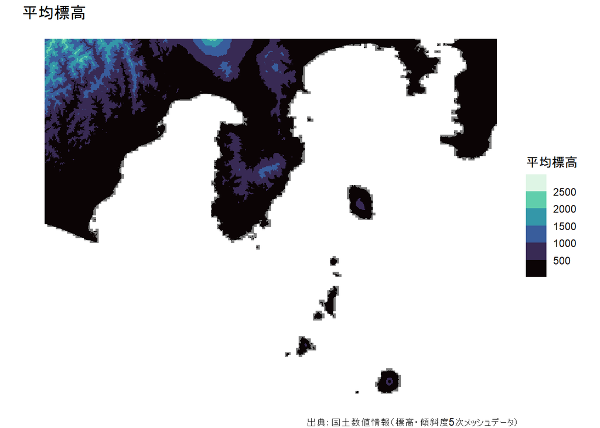

```r
ggplot()+
  geom_sf(data=mesh,
          aes(color=G04d_002,
              fill=G04d_002))+
  scale_color_viridis_b(option="G")+
  scale_fill_viridis_b(option="G")+
  labs(color="平均標高", fill="平均標高",
       caption="出典：国土数値情報（標高・傾斜度5次メッシュデータ）")+
  ggtitle("平均標高")+
  coord_sf(datum = NA)+
  theme_void()
```

# 3 行政区域データ

## 3.1 静岡県の行政区域データのダウンロード

- [国土数値情報ダウンロードサイト](https://nlftp.mlit.go.jp/ksj/index.html) > [行政区域（ポリゴン）](https://nlftp.mlit.go.jp/ksj/gml/datalist/KsjTmplt-N03-2024.html) > 静岡 世界測地系 2024年（令和6年） 10.9MB N03-20240101_22_GML.zip
  - ダウンロードしたZIPファイルを展開し作業フォルダに格納．

```r
#行政区域データの読込
Shizuoka <-
  read_sf("N03-20240101_22_GML/N03-20240101_22.shp")
```

## 3.2 伊豆地域の抽出

- `filter`を用いて伊豆地域の市町を抽出．

```r
Izu <- Shizuoka %>%
  filter(N03_004=="沼津市" |
           N03_004=="三島市" |
           N03_004=="函南町" |
           N03_004=="熱海市" |
           N03_004=="伊豆の国市" |
           N03_004=="伊豆市" |
           N03_004=="伊東市" |
           N03_004=="東伊豆市" |
           N03_004=="下田市" |
           N03_003=="賀茂郡")
```

- 伊豆地域を1つのポリゴンに変更．
  - 上の市町で共通なのは静岡県内に位置すること．そこで`N03_001`列（すべての要素が`静岡県`）で1つにまとめる．

```r
Izu %>%
  group_by(N03_001) %>%
  summarise() ->
  Izu
```

## 3.3 伊豆地域の可視化

- 白枠が伊豆地域．

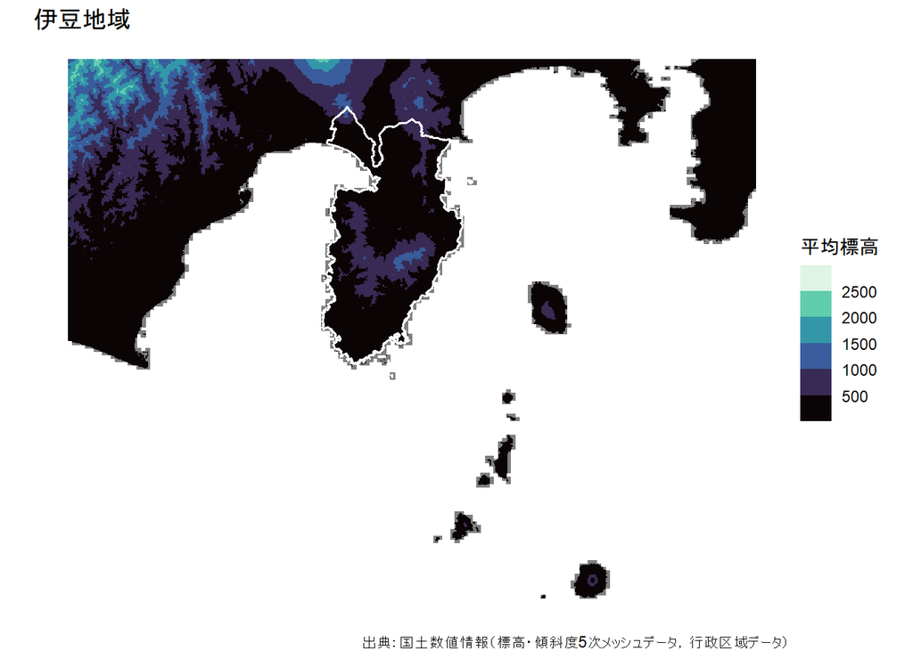

```r
ggplot()+
  geom_sf(data=mesh,
          aes(color=G04d_002,
              fill=G04d_002))+
  scale_color_viridis_b(option="G")+
  scale_fill_viridis_b(option="G")+
  geom_sf(data=Izu,
          color="white", fill="NA",
          linewidth=0.6)+
  labs(color="平均標高", fill="平均標高",
       caption="出典：国土数値情報（標高・傾斜度5次メッシュデータ，行政区域データ）")+
  ggtitle("伊豆地域")+
  coord_sf(datum = NA)+
  theme_void()
```

# 4 メッシュと伊豆地域行政区域の結合

- `mesh`と`Izu`を結合．`st_intersection()`を用いて共通部分を抽出．

```r
#Warning（警告）を出さないため
st_agr(mesh)="constant"
st_agr(Izu)="constant"

#結合
mesh_izu <-
  st_intersection(mesh, Izu)
```

## 4.1 伊豆地域の平均標高の可視化

- 平均標高の目盛り位置を手動で指定し，オブジェクト名を`my_breaks`とする．

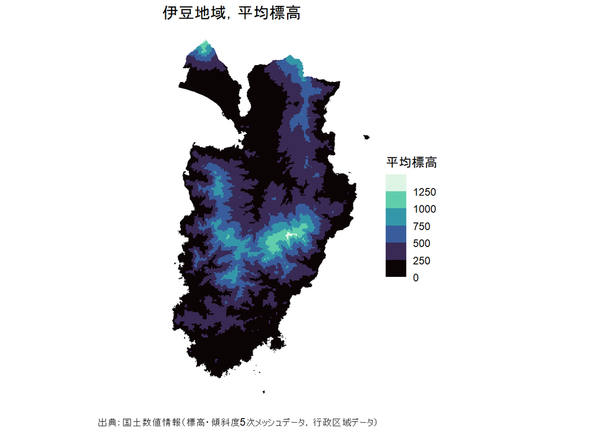

```r
my_breaks <- c(0, 250, 500, 750, 1000, 1250)


ggplot()+
  geom_sf(data=mesh_izu,
          aes(color=G04d_002,
              fill=G04d_002))+
  scale_color_viridis_b(option="G", breaks=my_breaks)+
  scale_fill_viridis_b(option="G", breaks=my_breaks)+
  labs(color="平均標高", fill="平均標高",
       caption="出典：国土数値情報（標高・傾斜度5次メッシュデータ，行政区域データ）")+
  ggtitle("伊豆地域，平均標高")+
  theme_void()
```

## 4.2 伊豆地域の平均傾斜角度の可視化

- `scale_color_viridis_c()`，`scale_fill_viridis_c()`：連続的な値として可視化．

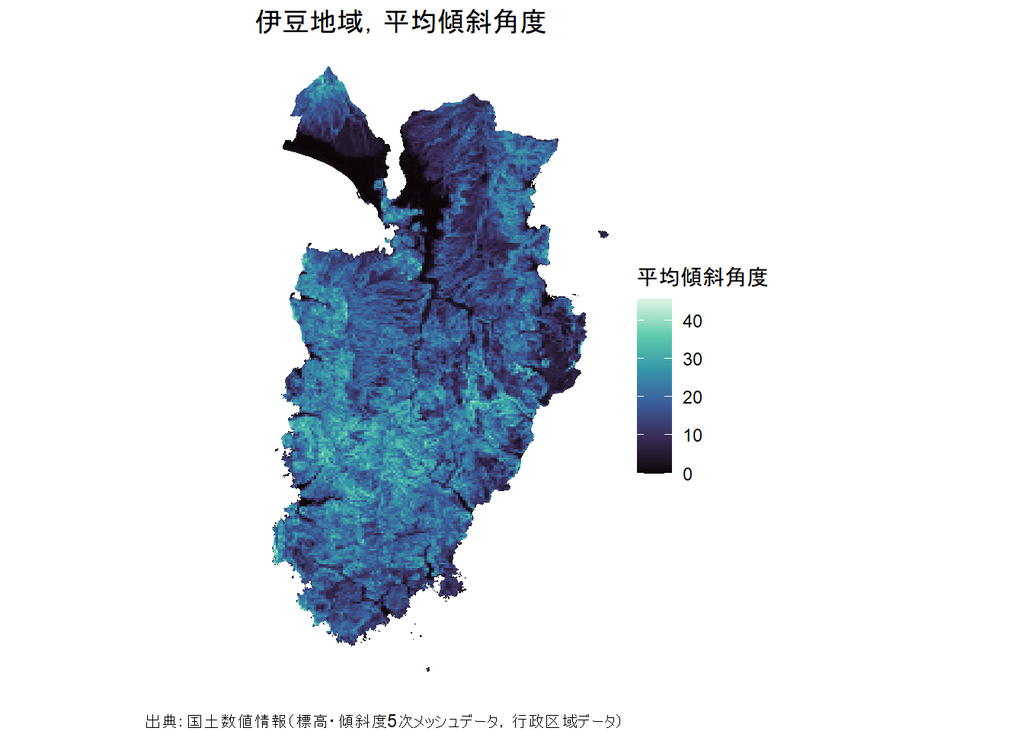

```r
ggplot()+
  geom_sf(data=mesh_izu,
          aes(color=G04d_010,
              fill=G04d_010))+
  scale_color_viridis_c(option="G")+
  scale_fill_viridis_c(option="G")+
  labs(color="平均傾斜角度", fill="平均傾斜角度",
       caption="出典：国土数値情報（標高・傾斜度5次メッシュデータ，行政区域データ）")+
  ggtitle("伊豆地域，平均傾斜角度")+
  theme_void()
```

**Rによる地理空間データの可視化**

- チュートリアル[ホーム](https://shinichiro-iwata.github.io/geospatial-data-visualization/)